# MEDL_HW02

**Deep Learning for Mechanical Engineering**  
**Homework 02**  
**Due Tuesday, 04/07/2020, 3:30 PM**

TA: Kangsan Lee and Namjeong Lee  
Instructor: Prof. Seungchul Lee  
http://iai.postech.ac.kr/  
Industrial AI Lab at POSTECH

- For your handwritten solution, scan or take a picture of them.
- For your code, only .ipynb file will be graded.
  - Please write your NAME and student ID on your .ipynb files. ex) KangsanLee_20202467_HW02.ipynb
- Please compress all the files to make a single .zip file
  - Please write your NAME and student ID on your .zip files. ex) NamjeongLee_20202467_HW02.zip
  - Submit it to LSM
- Do not submit a printed version of your code. It will not be graded.

# Problem 1: Linear System with TensorFlow

You will solve the following system of linear equations using some methods of the TensorFlow:

$$ \begin{align*} x + 2y - 3z = 4\\ x - y - z = 0\\ 2x + y - 2z = 6 \end{align*} $$

The objective of following questions is to find a vector $(x, y, z)$.

(0) Start with importing modules.

```python
import numpy as np
import tensorflow as tf
```

(a) Use `tf.constant` to find $x$.

```python
A_unshaped = tf.constant([1, 2, -3, 1, -1, -1, 2, 1, -2], dtype=tf.float32)
b_unshaped = tf.constant([4, 0, 6], dtype=tf.float32)
```

```python
# Your code here
A = tf.reshape( )
b = tf.reshape( )
A_inv = tf.linalg.inv(A)

x =

with tf.Session() as sess:
    result =
    print('x:\n', result)
```

```
x:
 [[3.]
 [2.]
 [1.]]
```

(b) You have a random matrix here. Use `tf.placeholder` to find $x$.

```python
# Your code here
A_rand = np.random.randint(-10, 10, size=(3, 3)).astype(np.float32)
b_rand = np.random.randint(-10, 10, size=(3, 1)).astype(np.float32)
print('A:\n', A_rand)
print('b:\n', b_rand)

A = tf.placeholder( )
b = tf.placeholder( )
A_inv =

x =
with tf.Session() as sess:
    result =
    print('x:\n', result)
```

```
A:
 [[-10.   9.  -6.]
 [  2.   6.  -3.]
 [ -7.   2.   5.]]
b:
 [[-3.]
 [ 2.]
 [ 5.]]
x:
 [[0.3296089 ]
 [0.79515815]
 [1.143389  ]]
```

(c) You will design an objective function and optimize it to find $x$. Use `tf.Variable`.

- hint: `tf.reduce_mean`, `tf.math.square`, `tf.train.GradientDescentOptimizer().minimize()`

```python
# Your code here
x = tf.Variable([[0], [0], [0]], dtype=tf.float32)
A = tf.reshape(A_unshaped, [3, 3])
b = tf.reshape(b_unshaped, [3, 1])
LearningRate = 0.1

cost =
optm =
init =

sess = tf.Session()
sess.run( )

for _ in range(500):
    sess.run( )

print('x:\n', sess.run(x))
```

```
x:
 [[2.9999988 ]
 [1.9999994 ]
 [0.99999905]]
```

# Problem 2: Digit Classification

In this problem, we will try to classify handwritten digits. For the sake of simplicity, we simplify this digit classification problem into a binary classification between digit 0 and digit 1.

## Step 1. Load the Data

| Data | Data dexcription |
| --- | --- |
| 0 | 1000 images (28×28 pixels) of handwritten digit 0 |
| 1 | 1000 images (28×28 pixels) of handwritten digit 1 |

- [Download data](https://www.dropbox.com/s/aokbzv5cy2rbmzy/data.pkl?dl=1) to read the files in Python.

To read the files in Python, use the following code:

```python
import matplotlib.pyplot as plt
from six.moves import cPickle
import numpy as np
data = cPickle.load(open('./data_files/data.pkl', 'rb'))
data0 = data['0']
data1 = data['1']
```

Here, we loaded 1000 numbers of data from ‘0’ and ‘1’. To display the image, use `plt.imshow(img)`.

- Note: make sure you are reading the files correctly. Check by displaying the few random images in each class.
- Note: calculations are more manageable if you go though and convert each of the pixels in $28\times28$ matrix to a binary value first.

(1) Display the few random images in each class.

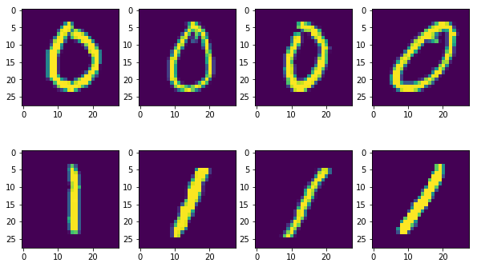

```python
# Your code here
```

(2) Convert each of the pixels in 28×28 matrix to a binary value.

```python
# Your code here
```

## Step 2. Extract Features

Now we must select ‘features’ from image data to detect digit 0 and digit 1. Two features are recommended

$\;\;$ (a) The total average pixels located at the center of the image (`img[10:20,10:20]`).

$\;\;$ (b) The total average pixels over the entire image.

$\;\;$ (c) Include the ones as our bias term.

$$\Phi(x) = \begin{bmatrix} 1 \\ \text{feature1}\\ \text{feature2} \end{bmatrix}$$

You should end up with a $2000\times3$ input matrix with the first $1000$ rows correspond to all of the ‘`data0`’ and the second 1000 rows correspond to the two features for all of the given ‘`data1`’.

```python
# Your code here
```

```
(2000, 3)
```

## Step 3. Plot the Data

Plot the data to see if classes are separable. The expected plot is the following:

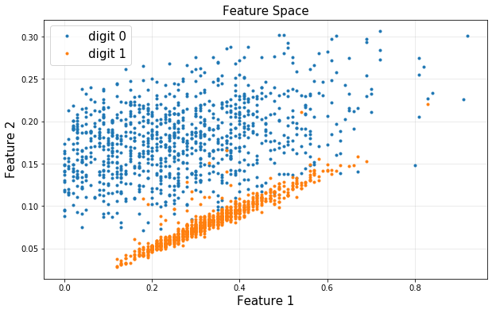

```python
# Your code here
```

## Step 4. Digit Classification with Logistic Regrssion

```python
from sklearn import linear_model
```

(1) Use the logistic regression algorithm to classify digit0 and digit1 data set.

$\;\;\;$ Note: you don't need to implement full algorithm by yourself. Just use sklearn library which we have learned in class.

```python
# Your code here
```

```
LogisticRegression(C=1.0, class_weight=None, dual=False, fit_intercept=True,
          intercept_scaling=1, max_iter=100, multi_class='warn',
          n_jobs=None, penalty='l2', random_state=None, solver='warn',
          tol=0.0001, verbose=0, warm_start=False)
```

(2) Plot the classifier (decision boundary).

$\;\;\;$ Note that the decision boundary is given:

$$\omega_1 x_1 + \omega_2x_2 + \omega_0 = 0$$

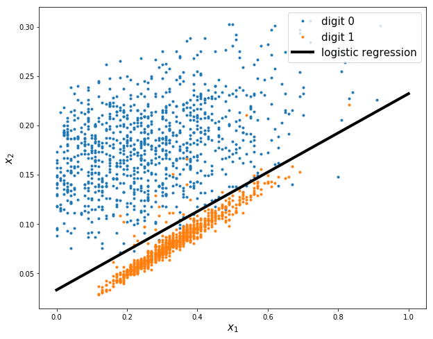

```python
# Your code here
```

# Problem 3: Logistic Regression with Gradient Descent

In this problem, we are going to classify randomly generated data set by the logistic regression algorithm with gradient descent.

Note: you need to write down full codes for this problem by yourself. Do not just use sklearn library.

```python
import numpy as np
import matplotlib.pyplot as plt
```

Here is the shape of $\omega$ and $x$.

$$ \begin{align*} \omega &= \begin{bmatrix} \omega_0 \\ \omega_1 \\ \omega_2\end{bmatrix}, \qquad x = \begin{bmatrix} 1 \\ x_1 \\ x_2\end{bmatrix}\\ \\ X &= \begin{bmatrix} \left(x^{(1)}\right)^T \\ \left(x^{(2)}\right)^T \\ \left(x^{(3)}\right)^T \\ \vdots\end{bmatrix} = \begin{bmatrix} 1 & x_1^{(1)} & x_2^{(1)} \\ 1 & x_1^{(2)} & x_2^{(2)} \\ 1 & x_1^{(3)} & x_2^{(3)} \\ \vdots & \vdots & \vdots \\\end{bmatrix}, \qquad y = \begin{bmatrix} y^{(1)}\\ y^{(2)} \\y^{(3)} \\ \vdots \end{bmatrix} \end{align*} $$

## Step 1. Data Generation

(1) [hand written] Write the gradient of log likelihood.

(2) Generate the data set by the following description.

- Generate 100 numbers of data
- Initialize $\omega$ as column vector of $[[-6],[2],[1]]^T$
- Generate the feature 1 and feature 2 with random numbers between 0~4.

(3) Now, we have a data set without a label. Then, label all the data as C1 if the logistic function output is larger than 0.5 and C0 otherwise.

$\;\;\;$ Note: you can use numpy function ‘`np.where`’ for this step.

(4) After labeling all the data, plot them to check it.

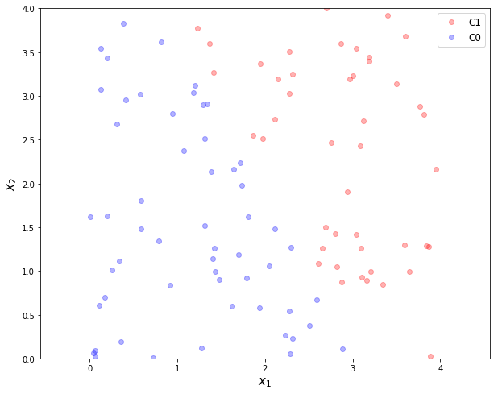

```python
# Your code here
```

## Step 2. Define Sigmoid Function

Define the sigmoid (logistic) function.

$$h_{\omega}(x) = h(x\,;\omega) = \sigma \left(\omega^T x\right) = \frac{1}{1+e^{-\omega^T x}}$$

```python
# Your code here

def h():
    return
```

## Step 3. Gradient Descent

(1) [hand written] Write the gradient descent algorithm for this problem.

$\;\;\;$ Note: this problem is maximization problem.

(2) Initialize $\omega$ and update it by gradient descent method.

```python
# Your code here
```

```
[[-34.84537161]
 [ 11.09387199]
 [  6.24487604]]
```

(3) Plot the classifier with the data.

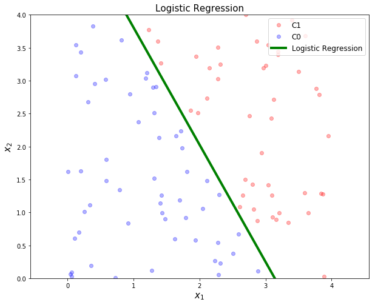

```python
# Your code here
```